# Time Series Analysis

## resample()

A common operation with time series data is resampling based on the time series index. Let's see how to use the resample() method. [[reference](https://pandas.pydata.org/pandas-docs/stable/generated/pandas.DataFrame.resample.html)]

```python
df.index
```

```
DatetimeIndex(['1980-12-12', '1980-12-15', '1980-12-16', '1980-12-17',
               '1980-12-18', '1980-12-19', '1980-12-22', '1980-12-23',
               '1980-12-24', '1980-12-26',
               ...
               '2019-09-19', '2019-09-20', '2019-09-23', '2019-09-24',
               '2019-09-25', '2019-09-26', '2019-09-27', '2019-09-30',
               '2019-10-01', '2019-10-02'],
              dtype='datetime64[ns]', name='Date', length=9785, freq=None)
```

When calling `.resample()` you first need to pass in a **rule** parameter, then you need to call some sort of aggregation function.

The **rule** parameter describes the frequency with which to apply the aggregation function (daily, monthly, yearly, etc.)  
It is passed in using an "offset alias" - refer to the table below. [[reference](http://pandas.pydata.org/pandas-docs/stable/user_guide/timeseries.html#offset-aliases)]

The aggregation function is needed because, due to resampling, we need some sort of mathematical rule to join the rows (mean, sum, count, etc.)

| Alias | Description |
| --- | --- |
| B | business day frequency |
| C | custom business day frequency |
| D | calendar day frequency |
| W | weekly frequency |
| M | month end frequency |
| SM | semi-month end frequency (15th and end of month) |
| BM | business month end frequency |
| CBM | custom business month end frequency |
| MS | month start frequency |
| SMS | semi-month start frequency (1st and 15th) |
| BMS | business month start frequency |
| CBMS | custom business month start frequency |
| Q | quarter end frequency |
| BQ | business quarter end frequency |
| QS | quarter start frequency |
| BQS | business quarter start frequency |
| A, Y | year end frequency |
| BA, BY | business year end frequency |
| AS, YS | year start frequency |
| BAS, BYS | business year start frequency |
| BH | business hour frequency |
| H | hourly frequency |
| T, min | minutely frequency |
| S | secondly frequency |
| L, ms | milliseconds |
| U, us | microseconds |
| N | nanoseconds |

```python
# Yearly Means
df.resample(rule='A').mean().head()
```

| Date | Open | High | Low | Close | Adj Close | Volume |
| --- | --- | --- | --- | --- | --- | --- |
| 1980-12-31 | 0.544299 | 0.545845 | 0.543613 | 0.543613 | 0.433044 | 2.586252e+07 |
| 1981-12-31 | 0.435472 | 0.437004 | 0.434125 | 0.434125 | 0.345826 | 8.131889e+06 |
| 1982-12-31 | 0.341782 | 0.346661 | 0.338518 | 0.341835 | 0.272308 | 2.111167e+07 |
| 1983-12-31 | 0.669096 | 0.684341 | 0.653797 | 0.669096 | 0.533005 | 4.398519e+07 |
| 1984-12-31 | 0.479822 | 0.489175 | 0.470567 | 0.478605 | 0.381259 | 4.148126e+07 |

```python
# Quaterly Mean
df.resample(rule='Q').mean().head()
```

| Date | Open | High | Low | Close | Adj Close | Volume |
| --- | --- | --- | --- | --- | --- | --- |
| 1980-12-31 | 0.544299 | 0.545845 | 0.543613 | 0.543613 | 0.433044 | 2.586252e+07 |
| 1981-03-31 | 0.494996 | 0.496436 | 0.493340 | 0.493340 | 0.392997 | 6.577923e+06 |
| 1981-06-30 | 0.519168 | 0.520904 | 0.517893 | 0.517893 | 0.412556 | 8.245689e+06 |
| 1981-09-30 | 0.387472 | 0.388676 | 0.385877 | 0.385877 | 0.307392 | 7.776711e+06 |
| 1981-12-31 | 0.342669 | 0.344413 | 0.341797 | 0.341797 | 0.272277 | 9.874900e+06 |

*Plotting these aggregations using pandas*

```python
# Yearly Mean
df.resample(rule='A').mean()['Close'].plot.bar(figsize=(15,5), title='Yearly Mean of apple stocks closing price')
```

[output not shown]

*We will discuss more on plotting in the last section*

## Time Shifting

### .shift() forward

This method shifts the entire date index a given number of rows, without regard for time periods (months & years)

```python
df.head()
```

| Date | Open | High | Low | Close | Adj Close | Volume |
| --- | --- | --- | --- | --- | --- | --- |
| 1980-12-12 | 0.513393 | 0.515625 | 0.513393 | 0.513393 | 0.408971 | 117258400.0 |
| 1980-12-15 | 0.488839 | 0.488839 | 0.486607 | 0.486607 | 0.387633 | 43971200.0 |
| 1980-12-16 | 0.453125 | 0.453125 | 0.450893 | 0.450893 | 0.359183 | 26432000.0 |
| 1980-12-17 | 0.462054 | 0.464286 | 0.462054 | 0.462054 | 0.368074 | 21610400.0 |
| 1980-12-18 | 0.475446 | 0.477679 | 0.475446 | 0.475446 | 0.378743 | 18362400.0 |

```python
df.shift(1).head()
```

| Date | Open | High | Low | Close | Adj Close | Volume |
| --- | --- | --- | --- | --- | --- | --- |
| 1980-12-12 | NaN | NaN | NaN | NaN | NaN | NaN |
| 1980-12-15 | 0.513393 | 0.515625 | 0.513393 | 0.513393 | 0.408971 | 117258400.0 |
| 1980-12-16 | 0.488839 | 0.488839 | 0.486607 | 0.486607 | 0.387633 | 43971200.0 |
| 1980-12-17 | 0.453125 | 0.453125 | 0.450893 | 0.450893 | 0.359183 | 26432000.0 |
| 1980-12-18 | 0.462054 | 0.464286 | 0.462054 | 0.462054 | 0.368074 | 21610400.0 |

```python
# Shifting backwards
df.shift(-1).tail()
```

| Date | Open | High | Low | Close | Adj Close | Volume |
| --- | --- | --- | --- | --- | --- | --- |
| 2019-09-26 | 220.539993 | 220.960007 | 217.279999 | 218.820007 | 218.820007 | 25352000.0 |
| 2019-09-27 | 220.899994 | 224.580002 | 220.789993 | 223.970001 | 223.970001 | 25977400.0 |
| 2019-09-30 | 225.070007 | 228.220001 | 224.199997 | 224.589996 | 224.589996 | 34805800.0 |
| 2019-10-01 | 223.059998 | 223.580002 | 217.929993 | 218.960007 | 218.960007 | 34612300.0 |
| 2019-10-02 | NaN | NaN | NaN | NaN | NaN | NaN |

```python
# Shift everything forward one month
df.shift(periods=1, freq='M').head()
```

| Date | Open | High | Low | Close | Adj Close | Volume |
| --- | --- | --- | --- | --- | --- | --- |
| 1980-12-31 | 0.513393 | 0.515625 | 0.513393 | 0.513393 | 0.408971 | 117258400.0 |
| 1980-12-31 | 0.488839 | 0.488839 | 0.486607 | 0.486607 | 0.387633 | 43971200.0 |
| 1980-12-31 | 0.453125 | 0.453125 | 0.450893 | 0.450893 | 0.359183 | 26432000.0 |
| 1980-12-31 | 0.462054 | 0.464286 | 0.462054 | 0.462054 | 0.368074 | 21610400.0 |
| 1980-12-31 | 0.475446 | 0.477679 | 0.475446 | 0.475446 | 0.378743 | 18362400.0 |

**More on [Shifting](http://pandas.pydata.org/pandas-docs/stable/generated/pandas.DataFrame.shift.html)**

## Rolling

A common process with time series is to create data based off of a rolling mean. The idea is to divide the data into "windows" of time, and then calculate an aggregate function for each window. In this way we obtain a simple moving average.

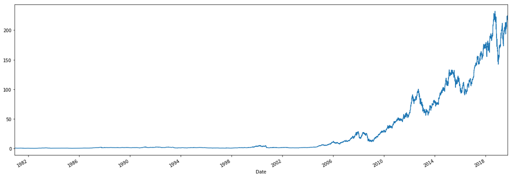

```python
df['Close'].plot(figsize=(20,7)).autoscale(axis='x',tight=True);
```

```python
# 7 day rolling mean
df.rolling(window=7).mean()['Close'].head(10)
```

```
Date
1980-12-12         NaN
1980-12-15         NaN
1980-12-16         NaN
1980-12-17         NaN
1980-12-18         NaN
1980-12-19         NaN
1980-12-22    0.488839
1980-12-23    0.494260
1980-12-24    0.507653
1980-12-26    0.533801
Name: Close, dtype: float64
```

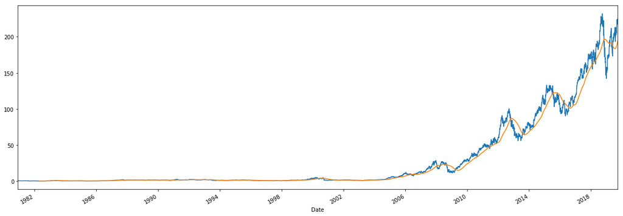

```python
df['Close'].plot(figsize=(20,7)).autoscale(axis='x',tight=True)
df.rolling(window=180).mean()['Close'].plot(); # 6 Months Rolling Mean
```

**Lets zoom on a bit on the rolling mean and see the plot after 2006**

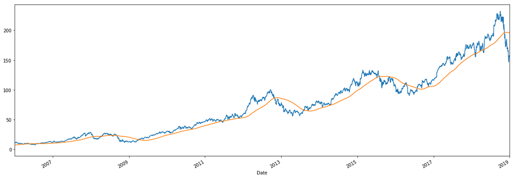

```python
df['Close'].plot(figsize=(20,7), xlim= ['2006-01-01', '2019-01-01']).autoscale(axis='x', tight=True)
df.rolling(window=180).mean()['Close'].plot(xlim= ['2006-01-01', '2019-01-01']); # 6 Months Rolling Mean
```

## Expanding

An expanding window refers to a model that calculates a statistic on all available historic data and uses that to make a forecast.

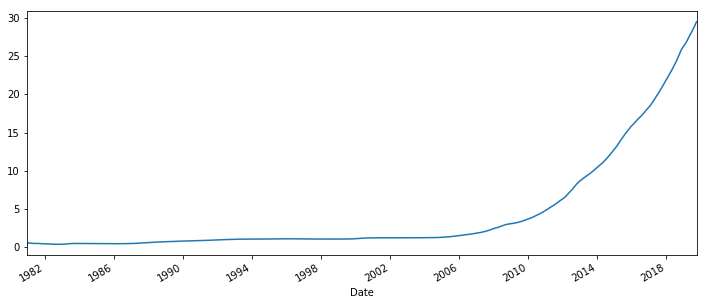

```python
df['Close'].expanding(min_periods=7).mean().plot(figsize=(12,5));
```

## Plotting time series data

```python
%matplotlib inline
```

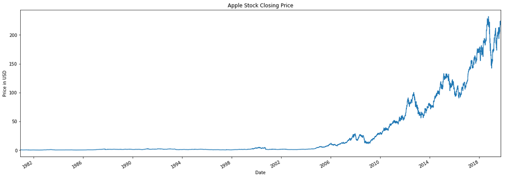

```python
title='Apple Stock Closing Price'
ylabel='Price in USD'
xlabel='Date'

ax = df['Close'].plot(figsize=(20,7),title=title)
ax.autoscale(axis='x',tight=True)
ax.set(xlabel=xlabel, ylabel=ylabel);
```

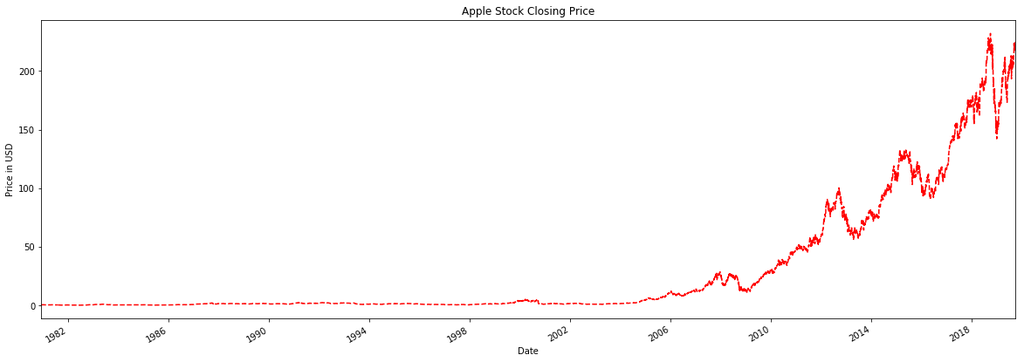

```python
# Color and line
ax = df['Close'].plot(figsize=(20,7),title=title, ls= '--', c='r')
ax.autoscale(axis='x',tight=True)
ax.set(xlabel=xlabel, ylabel=ylabel);
```

### Set the spacing

The x-axis values can be divided into major and minor axes. For now, we'll work only with the major axis and learn how to set the spacing with `.set_major_locator()`.

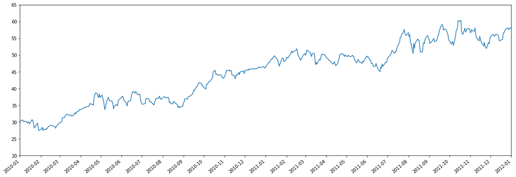

```python
# Formatting X-axis label
from matplotlib import dates
import matplotlib.pyplot as plt

ax = df['Close'].plot(figsize=(20,7), xlim= ['2010-01-01', '2012-01-01'],ylim= [20,65], rot=40) # limiting the date to two years 2010 to 2012

# REMOVE PANDAS DEFAULT "Date" LABEL
ax.set(xlabel='')

# SET THE TICK LOCATOR AND FORMATTER FOR THE MAJOR AXIS
ax.xaxis.set_major_locator(dates.MonthLocator(bymonthday=1))
```

### Date Formatting

Formatting follows the Python datetime strftime codes.

| Code | Meaning | Example |
| --- | --- | --- |
| `%a` | Weekday as locale’s abbreviated name. | `Mon` |
| `%A` | Weekday as locale’s full name. | `Monday` |
| `%w` | Weekday as a decimal number, where 0 is Sunday and 6 is Saturday. | `1` |
| `%d` | Day of the month as a zero-padded decimal number. | `30` |
| `%-d` | Day of the month as a decimal number. (Platform specific) | `30` |
| `%b` | Month as locale’s abbreviated name. | `Sep` |
| `%B` | Month as locale’s full name. | `September` |
| `%m` | Month as a zero-padded decimal number. | `09` |
| `%-m` | Month as a decimal number. (Platform specific) | `9` |
| `%y` | Year without century as a zero-padded decimal number. | `13` |
| `%Y` | Year with century as a decimal number. | `2013` |
| `%H` | Hour (24-hour clock) as a zero-padded decimal number. | `07` |
| `%-H` | Hour (24-hour clock) as a decimal number. (Platform specific) | `7` |
| `%I` | Hour (12-hour clock) as a zero-padded decimal number. | `07` |
| `%-I` | Hour (12-hour clock) as a decimal number. (Platform specific) | `7` |
| `%p` | Locale’s equivalent of either AM or PM. | `AM` |
| `%M` | Minute as a zero-padded decimal number. | `06` |
| `%-M` | Minute as a decimal number. (Platform specific) | `6` |
| `%S` | Second as a zero-padded decimal number. | `05` |
| `%-S` | Second as a decimal number. (Platform specific) | `5` |
| `%f` | Microsecond as a decimal number, zero-padded on the left. | `000000` |
| `%z` | UTC offset in the form +HHMM or -HHMM (empty string if the the object is naive). |  |
| `%Z` | Time zone name (empty string if the object is naive). |  |
| `%j` | Day of the year as a zero-padded decimal number. | `273` |
| `%-j` | Day of the year as a decimal number. (Platform specific) | `273` |
| `%c` | Locale’s appropriate date and time representation. | `Mon Sep 30 07:06:05 2013` |
| `%x` | Locale’s appropriate date representation. | `09/30/13` |
| `%X` | Locale’s appropriate time representation. | `07:06:05` |
| `%%` | A literal '%' character. | `%` |

```python
from datetime import datetime
datetime(2019, 10, 2, 16, 5, 6).strftime("%A, %B %d, %Y  %I:%M:%S %p")
```

```
'Wednesday, October 02, 2019  04:05:06 PM'
```

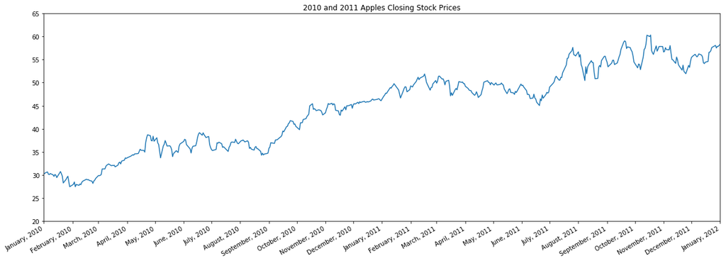

```python
ax = df['Close'].plot(figsize=(20,7), xlim= ['2010-01-01', '2012-01-01'],ylim=[20,65],title='2010 and 2011 Apples Closing Stock Prices')
ax.set(xlabel='')

ax.xaxis.set_major_locator(dates.MonthLocator(bymonthday=1))
# Date Formating
ax.xaxis.set_major_formatter(dates.DateFormatter("%B, %Y"))
```

### Major vs. Minor Axis Values

Till Now we have been using Major we can also specify a minor axis also.

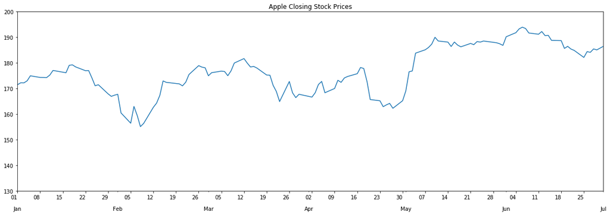

```python
ax = df['Close'].plot(figsize= (20,7), xlim=['2018-01-01','2018-07-01'],ylim= [130,200], rot=0,title='Apple Closing Stock Prices')
ax.set(xlabel='')

ax.xaxis.set_major_locator(dates.WeekdayLocator(byweekday=0))
ax.xaxis.set_major_formatter(dates.DateFormatter('%d'))

ax.xaxis.set_minor_locator(dates.MonthLocator())
ax.xaxis.set_minor_formatter(dates.DateFormatter('\n\n%b'))
```

## Box Plots

```python
groups = df.loc['2010-01-01':'2019-01-01']['Close'].groupby(pd.Grouper(freq='A'))
```

[output not shown]

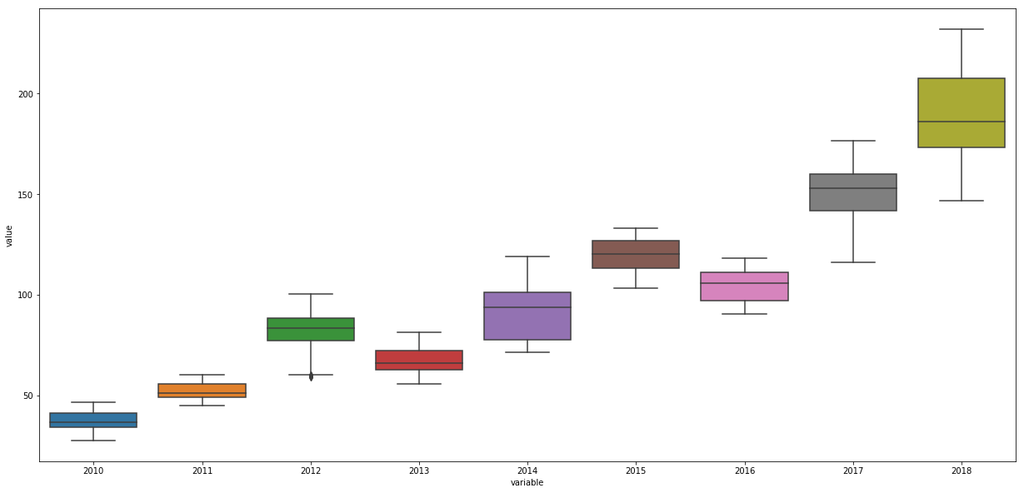

```python
import matplotlib.pyplot as plt
import seaborn as sns
years = pd.DataFrame()

for name, group in groups:
    years[str(name.year)] = pd.Series(group.values)

plt.figure(figsize= (21,10))
sns.boxplot(x="variable", y="value", data=pd.melt(years))
plt.plot()
```

# Components of Time Series

- Level. The baseline value for the series if it were a straight line.
- Trend. The optional and often linear increasing or decreasing behavior of the series over time.
- Seasonality. The optional repeating patterns or cycles of behavior over time.
- Noise. The optional variability in the observations that cannot be explained by the model.

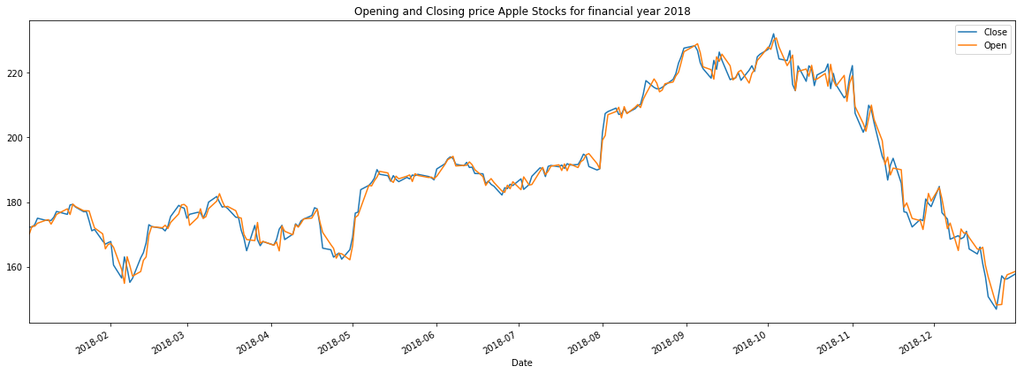

```python
df.loc['2018-01-01':'2019-01-01'][['Close', 'Open']].plot(figsize=(20,7),title= "Opening and Closing price Apple Stocks for financial year 2018").autoscale(axis='x',tight=True);
```

## Trends in Time Series

*A trend is a long-term increase or decrease in the level of the time series.*

A trend is often easily visualized as a line through the observations. Linear trends can be summarized by a linear model, and nonlinear trends may be best summarized using a polynomial or other curve-fitting method. Because of the subjective and domain-specific nature of identifying trends, this approach can help to identify whether a trend is present. Even fitting a linear model to a trend that is clearly super-linear or exponential can be helpful.

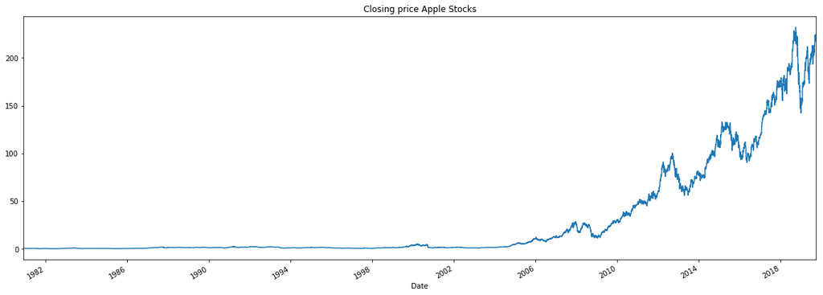

```python
df['Close'].plot(figsize=(20,7),title= "Closing price Apple Stocks").autoscale(axis='x',tight=True);
```

```python
import numpy as np
np.where(np.isnan(df.Close.values))
```

```
(array([165], dtype=int64),)
```

*We can see a null value in the dataset, So we can impute it using rolling mean and rolling mean makes more sense than simple mean.*

```python
df.Close= df.Close.fillna(df.Close.rolling(24,min_periods=1,).mean())
```

```python
from sklearn.linear_model import LinearRegression
X = [i for i in range(0, df.shape[0])]
X = np.reshape(X, (len(X), 1))
y = df.Close.values
model = LinearRegression()
model.fit(X, y)
```

```
LinearRegression(copy_X=True, fit_intercept=True, n_jobs=None, normalize=False)
```

```python
# Predicting the trenf
trend = model.predict(X)
```

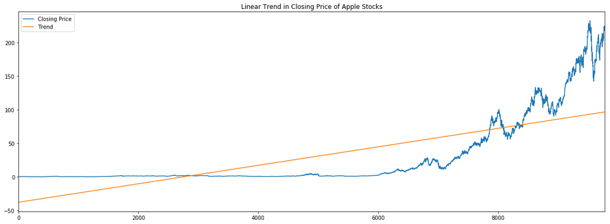

```python
import matplotlib.pyplot as plt
pd.DataFrame({"Closing Price": y, "Trend": trend}).plot(figsize=(20,7),title= "Linear Trend in Closing Price of Apple Stocks").autoscale(axis='x',tight=True);
```

### Using Statsmodels to get the trend

[Hodrick-Prescott filter](https://www.statsmodels.org/stable/generated/statsmodels.tsa.filters.hp_filter.hpfilter.html)

`statsmodels.tsa.filters.hp_filter.hpfilter(X, lamb=1600)`

The [Hodrick-Prescott filter](https://en.wikipedia.org/wiki/Hodrick%E2%80%93Prescott_filter) separates a time-series $y_t$ into a trend component $\tau_t$ and a cyclical component $c_t$

$y_t = \tau_t + c_t$

The components are determined by minimizing the following quadratic loss function, where $\lambda$ is a smoothing parameter:

$\min_{\\{ \tau_{t}\\} }\sum_{t=1}^{T}c_{t}^{2}+\lambda\sum_{t=1}^{T}\left[\left(\tau_{t}-\tau_{t-1}\right)-\left(\tau_{t-1}-\tau_{t-2}\right)\right]^{2}$

The $\lambda$ value above handles variations in the growth rate of the trend component.

When analyzing quarterly data, the default lambda value of 1600 is recommended. Use 6.25 for annual data, and 129,600 for monthly data.

### Quarterly Trend

```python
from statsmodels.tsa.filters.hp_filter import hpfilter
# Tuple unpacking
stock_cycle, stock_trend = hpfilter(df['Close'], lamb=1600)
```

```python
df['trend'] = stock_trend
```

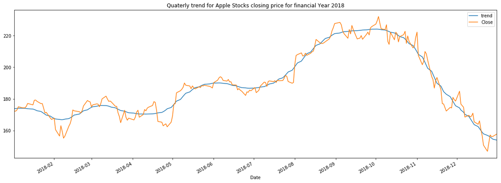

```python
df.loc['2018-01-01':'2019-01-01'][['trend','Close']].plot(figsize=(20,7), title= "Quaterly trend for Apple Stocks closing price for financial Year 2018").autoscale(axis='x',tight=True);
```

### Monthly Trends

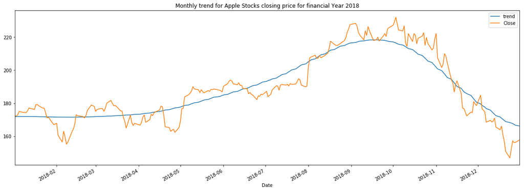

```python
from statsmodels.tsa.filters.hp_filter import hpfilter
# Tuple unpacking
stock_cycle, stock_trend = hpfilter(df['Close'], lamb=129600)
df['trend'] = stock_trend
df.loc['2018-01-01':'2019-01-01'][['trend','Close']].plot(figsize=(20,7), title= "Monthly trend for Apple Stocks closing price for financial Year 2018").autoscale(axis='x',tight=True);
```

### Yearly Trends

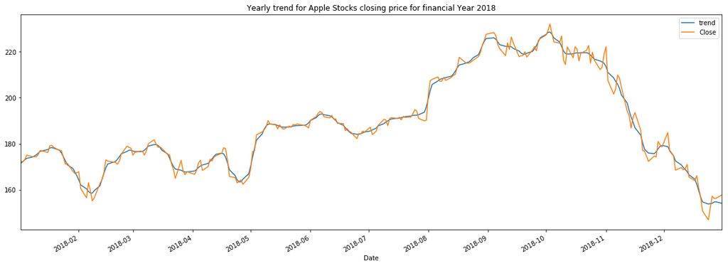

```python
from statsmodels.tsa.filters.hp_filter import hpfilter
# Tuple unpacking
stock_cycle, stock_trend = hpfilter(df['Close'], lamb=6.25)
df['trend'] = stock_trend
df.loc['2018-01-01':'2019-01-01'][['trend','Close']].plot(figsize=(20,7), title= "Yearly trend for Apple Stocks closing price for financial Year 2018").autoscale(axis='x',tight=True);
```

## Error/Trend/Seasonality Models

The decomposition of a time series attempts to isolate individual components such as error, trend, and seasonality **(ETS)**. We've already seen a simplistic example of this in the above section with the **Hodrick-Prescott filter**. There we separated data into a trendline and a cyclical feature that mapped observed data back to the trend.

There are two types of ETS model, One is **additive** model and other is **multipliactive** model.

*We apply a additive model when it seems that the trend is more linear and the (seasonality, trend) components seem to be constant over time.*

*A multiplicative model is more appropriate when we are increasing at a non-linear rate.*

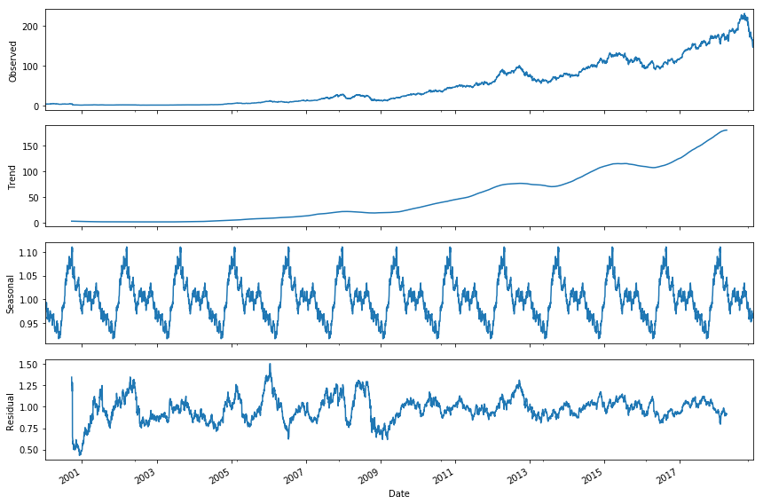

```python
from statsmodels.tsa.seasonal import seasonal_decompose
# Yearly trends
result = seasonal_decompose(df.loc['2000-01-01':'2019-01-01']['Close'], freq=364, model='mul')  # model='mul' also works
from pylab import rcParams
rcParams['figure.figsize']= 12,8
result.plot();
```

*Lets just look at the seasonality component.*

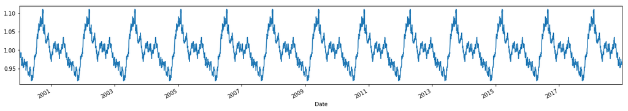

```python
from matplotlib import dates
ax= result.seasonal.plot(figsize=(20,3))
ax.autoscale(axis='x',tight=True);
```

*Now We can clearly see a seasonality here to get more detail on the seasonality lets make use of Statsmodel monthly and quaterly plots.*

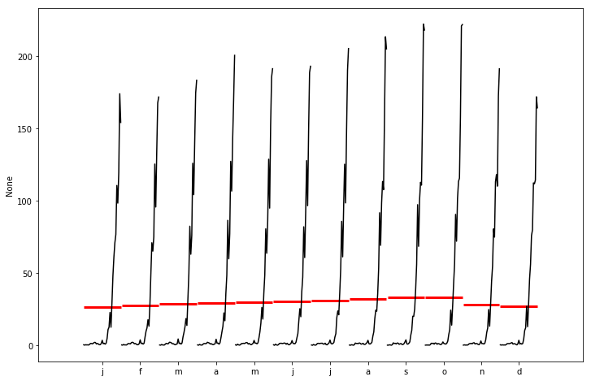

```python
from statsmodels.graphics.tsaplots import month_plot,quarter_plot
monthly = df.Close.resample(rule='M').mean()
month_plot(monthly);
```

*The lines show the range of values and red bar on it shows the mean, Clearly you can see that the means and range of values are higher in September and October.*

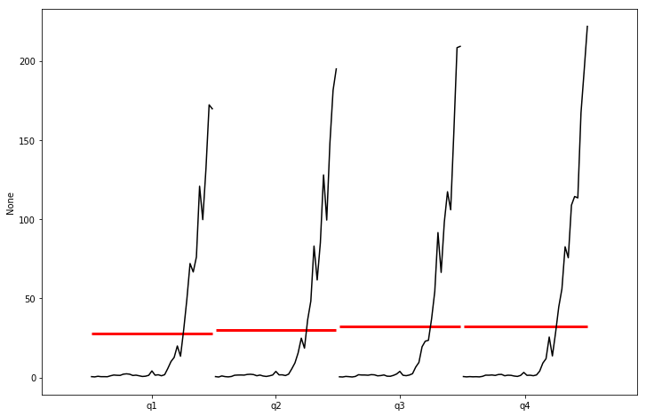

```python
quarter = df.Close.resample(rule='Q').mean()
quarter_plot(quarter);
```

## Stationarity

*Stationarity indicates that all statistical properties (statistical moments) of a time series, like mean, standard deviation etc. remains constant over the period of observation i.e. doesn’t depend on time.*

## Test for Stationarity

**Augmented Dickey-Fuller test**

- Null Hypothesis (H0): If accepted, it suggests the time series has a unit root, meaning it is non-stationary. It has some time dependent structure.
- Alternate Hypothesis (H1): The null hypothesis is rejected; it suggests the time series does not have a unit root, meaning it is stationary. It does not have time-dependent structure.
- p-value > 0.05: Accept the null hypothesis (H0), the data has a unit root and is non-stationary.
- p-value ≤ 0.05: Reject the null hypothesis (H0), the data does not have a unit root and is stationary.

```python
from statsmodels.tsa.stattools import adfuller
X= df.Close.values
result = adfuller(X)
print('ADF Statistic: %f' % result[0])
print('p-value: %f' % result[1])
print('Critical Values:')
for key, value in result[4].items():
    print('\t%s: %.3f' % (key, value))
```

```
ADF Statistic: 2.531279
p-value: 0.999059
Critical Values:
	1%: -3.431
	5%: -2.862
	10%: -2.567
```

**The p-value is greater than 0.05. So,We accept the null hypothesis (H0), the data has a unit root and is non-stationary**

#### Lets take a sample data where data is Stationary.

Download it from [here](https://drive.google.com/file/d/1JWcEYNCF-lViLHurQqYWDNq9NydD9mEn/view?usp=sharing)

This is genrated data for showing stationarity there is no meaning to it.

```python
df1 = pd.read_csv('Data/samples.csv',index_col=0,parse_dates=True)
df1.head()
```

|  | a | b | c | d |
| --- | --- | --- | --- | --- |
| 1950-01-01 | 36 | 27 | 0 | 67 |
| 1950-02-01 | 58 | 22 | 3 | 31 |
| 1950-03-01 | 61 | 17 | 5 | 67 |
| 1950-04-01 | 37 | 15 | 8 | 47 |
| 1950-05-01 | 66 | 13 | 8 | 62 |

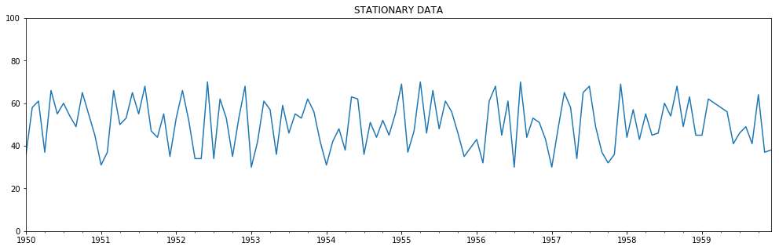

```python
df1['a'].plot(figsize= (17,5), ylim=[0,100],title="STATIONARY DATA").autoscale(axis='x',tight=True);
```

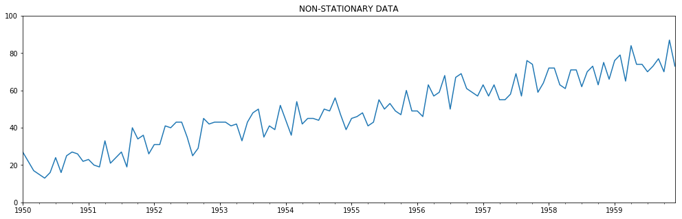

```python
df1['b'].plot(figsize= (17,5), ylim=[0,100],title="NON-STATIONARY DATA").autoscale(axis='x',tight=True);
```

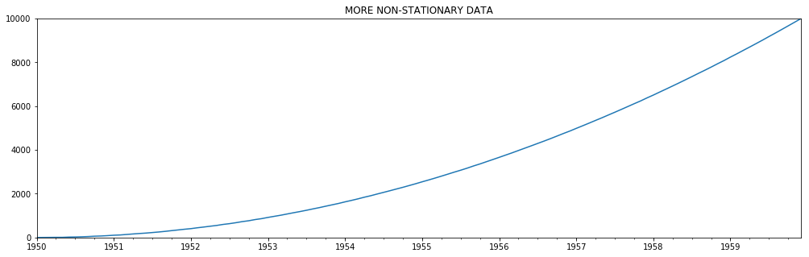

```python
df1['c'].plot(figsize= (17,5), ylim=[0,10000],title="MORE NON-STATIONARY DATA").autoscale(axis='x',tight=True);
```

**Lets do a stationarity test on first column which has Stationary Data**

```python
X= df1.a.values
result = adfuller(X)
print('ADF Statistic: %f' % result[0])
print('p-value: %f' % result[1])
print('Critical Values:')
for key, value in result[4].items():
    print('\t%s: %.3f' % (key, value))
```

```
ADF Statistic: -11.988522
p-value: 0.000000
Critical Values:
	1%: -3.487
	5%: -2.886
	10%: -2.580
```

**The p-value is less than 0.05. So, We reject the null hypothesis (H0), the data does not have a unit root and is stationary.**

### Converting Non-Stationary to Stationary

### First Order Differencing

Non-stationary data can be made to look stationary through *differencing*. A simple method called *first order differencing* calculates the difference between consecutive observations.

$y^{\prime}_t = y_t - y_{t-1}$

In this way a linear trend is transformed into a horizontal set of values.

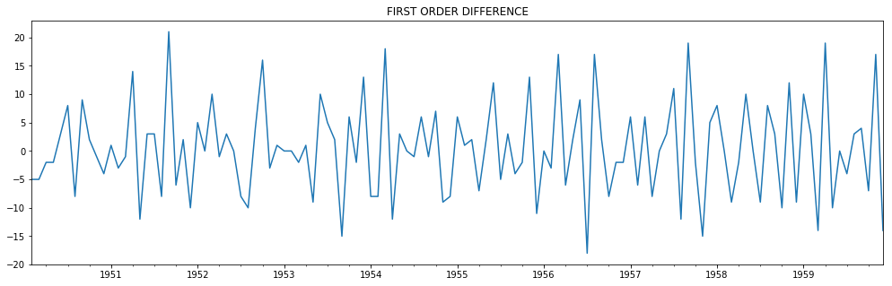

```python
# To get first order differencing just use .diff()
df1['d1b'] = df1['b'].diff()

df1['d1b'].plot(figsize= (17,5), title="FIRST ORDER DIFFERENCE").autoscale(axis='x',tight=True);
```

### Second order differencing

Sometimes the first difference is not enough to attain stationarity, particularly if the trend is not linear. We can difference the already differenced values again to obtain a second order set of values.

$\begin{split}y_{t}^{\prime\prime} &= y_{t}^{\prime} - y_{t-1}^{\prime} \\ &= (y_t - y_{t-1}) - (y_{t-1} - y_{t-2}) \\ &= y_t - 2y_{t-1} + y_{t-2}\end{split}$

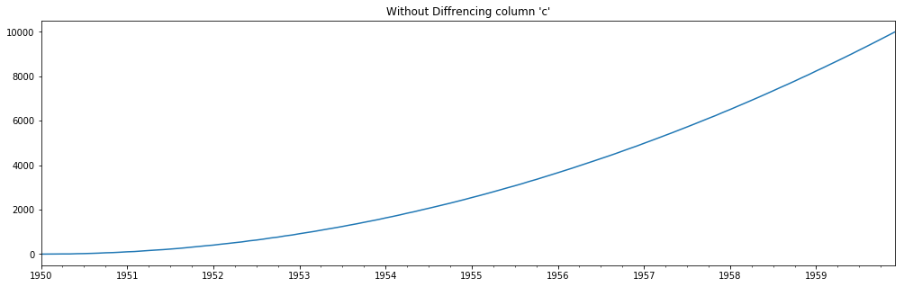

```python
df1['c'].plot(figsize= (17,5), title="Without Diffrencing column 'c'").autoscale(axis='x',tight=True);
```

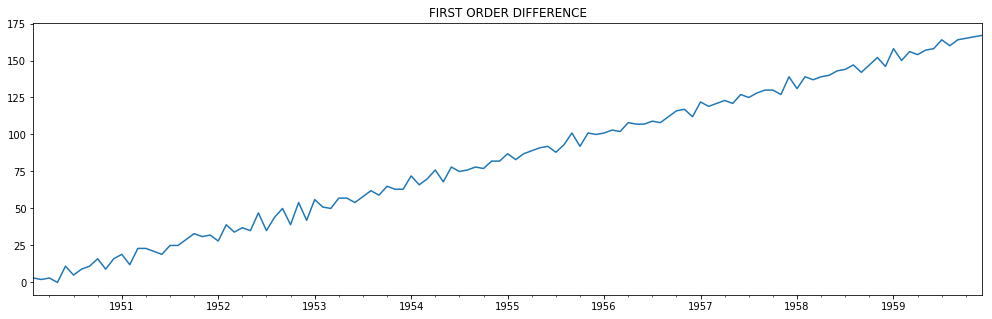

```python
# First we'll look at the first order difference of dataset column "c" which has an exponencial curve.
df1['d1c'] = df1['c'].diff()

df1['d1c'].plot(figsize= (17,5), title="FIRST ORDER DIFFERENCE").autoscale(axis='x',tight=True);
```

*As I told sometimes first order diffrence will not be efficient. Lets do a 2nd order diffrence.*

```python
# We can do this from the original time series in one step
df1['d2c'] = df1['c'].diff().diff()

df1[['c','d1c','d2c']].head()
```

|  | c | d1c | d2c |
| --- | --- | --- | --- |
| 1950-01-01 | 0 | NaN | NaN |
| 1950-02-01 | 3 | 3.0 | NaN |
| 1950-03-01 | 5 | 2.0 | -1.0 |
| 1950-04-01 | 8 | 3.0 | 1.0 |
| 1950-05-01 | 8 | 0.0 | -3.0 |

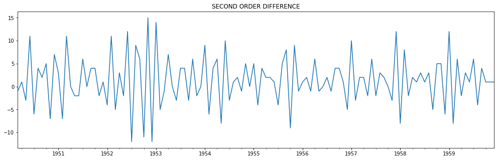

```python
df1['d2c'].plot(figsize= (17,5), title="SECOND ORDER DIFFERENCE").autoscale(axis='x',tight=True);
```

*Lets get hands on a real world dataset that is stationary*

**Daily Total Female Births**

*You can download the Dataset from [here](https://drive.google.com/file/d/1-P6s16dV6kIuaILeP8rFYxGdoMQ1zdAL/view?usp=sharing)*

```python
df2 = pd.read_csv('Data/DailyTotalFemaleBirths.csv',index_col='Date',parse_dates=True)
df2.index.freq = 'D'
```

```python
print('Augmented Dickey-Fuller Test on Daily Female Births')
dftest = adfuller(df2['Births'],autolag='AIC')
dfout = pd.Series(dftest[0:4],index=['ADF test statistic','p-value','# lags used','# observations'])

for key,val in dftest[4].items():
    dfout[f'critical value ({key})']=val
print(dfout)
```

```
Augmented Dickey-Fuller Test on Daily Female Births
ADF test statistic       -4.808291
p-value                   0.000052
# lags used               6.000000
# observations          358.000000
critical value (1%)      -3.448749
critical value (5%)      -2.869647
critical value (10%)     -2.571089
dtype: float64
```

*Now remembering the hypothesis is quite a burden on you. So I have create a function which is going to print out the a report.*

```python
def adf_test(series,title=''):
    """
    Pass in a time series and an optional title, returns an ADF report
    """
    print(f'Augmented Dickey-Fuller Test: {title}')
    result = adfuller(series.dropna(),autolag='AIC') # .dropna() handles differenced data

    labels = ['ADF test statistic','p-value','# lags used','# observations']
    out = pd.Series(result[0:4],index=labels)

    for key,val in result[4].items():
        out[f'critical value ({key})']=val

    print(out.to_string())          # .to_string() removes the line "dtype: float64"

    if result[1] <= 0.05:
        print("Strong evidence against the null hypothesis")
        print("Reject the null hypothesis")
        print("Data has no unit root and is stationary")
    else:
        print("Weak evidence against the null hypothesis")
        print("Fail to reject the null hypothesis")
        print("Data has a unit root and is non-stationary")
```

```python
adf_test(df2['Births'])
```

```
Augmented Dickey-Fuller Test:
ADF test statistic       -4.808291
p-value                   0.000052
# lags used               6.000000
# observations          358.000000
critical value (1%)      -3.448749
critical value (5%)      -2.869647
critical value (10%)     -2.571089
Strong evidence against the null hypothesis
Reject the null hypothesis
Data has no unit root and is stationary
```

*So the data is stationary and lets just plot it an see hoe it looks.*

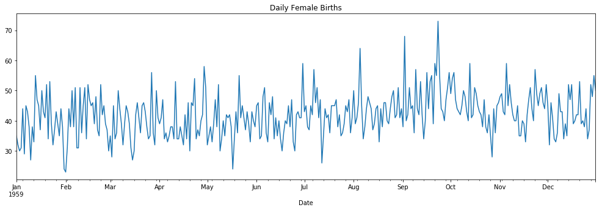

```python
df2['Births'].plot(figsize= (17,5), title="Daily Female Births").autoscale(axis='x',tight=True);
```

*From a naked eye you can see that there no is upward/downward trend or seasonality to it.*

# ACF and PACF

# Autocorrelation Function / Partial Autocorrelation Function

```python
# Load a non-stationary dataset
df1 = pd.read_csv('Data/airline_passengers.csv',index_col='Month',parse_dates=True)
df1.index.freq = 'MS'

# Load a stationary dataset
df2 = pd.read_csv('Data/DailyTotalFemaleBirths.csv',index_col='Date',parse_dates=True)
df2.index.freq = 'D'
```

```python
import warnings
warnings.filterwarnings("ignore")
```

```python
from statsmodels.tsa.stattools import acovf,acf,pacf,pacf_yw,pacf_ols
```

```python
from statsmodels.graphics.tsaplots import plot_acf,plot_pacf
```

## Autocorrelation Plots

### Stationary Data

```python
acf(df2['Births'])
```

```
array([ 1.        ,  0.21724118,  0.15287758,  0.10821254,  0.09066059,
        0.09595481,  0.09104012,  0.19508071,  0.14115295,  0.06117859,
        0.04781522,  0.04770662, -0.01964707,  0.02287422,  0.08112657,
        0.11185686,  0.07333732,  0.01501845,  0.07270333,  0.06859   ,
        0.09280107,  0.26386846,  0.14012147,  0.06070286,  0.08716232,
        0.05038825,  0.0650489 ,  0.11466565,  0.1552232 ,  0.12850638,
        0.10358981,  0.09734643,  0.04912286,  0.04022798,  0.05838555,
        0.05359812,  0.10151053,  0.08268663,  0.0912185 ,  0.11192192,
        0.05652846])
```

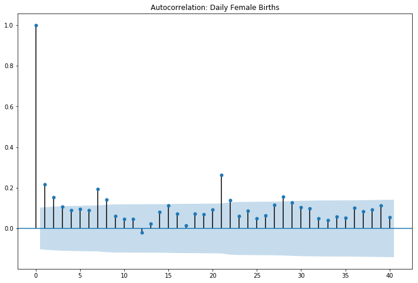

```python
# Now let's plot the autocorrelation at different lags
title = 'Autocorrelation: Daily Female Births'
lags = 40
plot_acf(df2,title=title,lags=lags);
```

### Non-Stationary Data

```python
acf(df1['Thousands of Passengers'])
```

```
array([1.        , 0.94804734, 0.87557484, 0.80668116, 0.75262542,
       0.71376997, 0.6817336 , 0.66290439, 0.65561048, 0.67094833,
       0.70271992, 0.74324019, 0.76039504, 0.71266087, 0.64634228,
       0.58592342, 0.53795519, 0.49974753, 0.46873401, 0.44987066,
       0.4416288 , 0.45722376, 0.48248203, 0.51712699, 0.53218983,
       0.49397569, 0.43772134, 0.3876029 , 0.34802503, 0.31498388,
       0.28849682, 0.27080187, 0.26429011, 0.27679934, 0.2985215 ,
       0.32558712, 0.3370236 , 0.30333486, 0.25397708, 0.21065534,
       0.17217092])
```

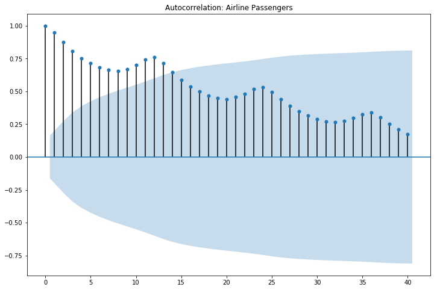

```python
title = 'Autocorrelation: Airline Passengers'
lags = 40
plot_acf(df1,title=title,lags=lags);
```